# fitbit project

john myers

2/21/2022

### The purpose of this project is to see if there are associations with using a fitbit device. We will look at sleep, calories, number of steps and distance just to name a few. We hope to see that the fitbit device is working correctly so we check number of steps vs calories to make sure we see an increase in calories with increase in steps.

### Load libraries

```r
library(tidyverse)
library(lubridate)
```

```r
library(ggcorrplot)
```

### Import the datasets

```r
data_day <- read.csv("Fitabase Data 4.12.16-5.12.16/dailyActivity_merged.csv")
head(data_day)
```

```
##           Id ActivityDate TotalSteps TotalDistance TrackerDistance
## 1 1503960366    4/12/2016      13162          8.50            8.50
## 2 1503960366    4/13/2016      10735          6.97            6.97
## 3 1503960366    4/14/2016      10460          6.74            6.74
## 4 1503960366    4/15/2016       9762          6.28            6.28
## 5 1503960366    4/16/2016      12669          8.16            8.16
## 6 1503960366    4/17/2016       9705          6.48            6.48
##   LoggedActivitiesDistance VeryActiveDistance ModeratelyActiveDistance
## 1                        0               1.88                     0.55
## 2                        0               1.57                     0.69
## 3                        0               2.44                     0.40
## 4                        0               2.14                     1.26
## 5                        0               2.71                     0.41
## 6                        0               3.19                     0.78
##   LightActiveDistance SedentaryActiveDistance VeryActiveMinutes
## 1                6.06                       0                25
## 2                4.71                       0                21
## 3                3.91                       0                30
## 4                2.83                       0                29
## 5                5.04                       0                36
## 6                2.51                       0                38
##   FairlyActiveMinutes LightlyActiveMinutes SedentaryMinutes Calories
## 1                  13                  328              728     1985
## 2                  19                  217              776     1797
## 3                  11                  181             1218     1776
## 4                  34                  209              726     1745
## 5                  10                  221              773     1863
## 6                  20                  164              539     1728
```

```r
data_sleep <- read.csv("Fitabase Data 4.12.16-5.12.16/sleepDay_merged.csv")
head(data_sleep)
```

```
##           Id              SleepDay TotalSleepRecords TotalMinutesAsleep
## 1 1503960366 4/12/2016 12:00:00 AM                 1                327
## 2 1503960366 4/13/2016 12:00:00 AM                 2                384
## 3 1503960366 4/15/2016 12:00:00 AM                 1                412
## 4 1503960366 4/16/2016 12:00:00 AM                 2                340
## 5 1503960366 4/17/2016 12:00:00 AM                 1                700
## 6 1503960366 4/19/2016 12:00:00 AM                 1                304
##   TotalTimeInBed
## 1            346
## 2            407
## 3            442
## 4            367
## 5            712
## 6            320
```

```r
data_c <- read.csv("Fitabase Data 4.12.16-5.12.16/dailyCalories_merged.csv")
head(data_c)
```

```
##           Id ActivityDay Calories
## 1 1503960366   4/12/2016     1985
## 2 1503960366   4/13/2016     1797
## 3 1503960366   4/14/2016     1776
## 4 1503960366   4/15/2016     1745
## 5 1503960366   4/16/2016     1863
## 6 1503960366   4/17/2016     1728
```

### Check missing values

```r
data_day %>% is.na() %>% colMeans()
```

```
##                       Id             ActivityDate               TotalSteps
##                        0                        0                        0
##            TotalDistance          TrackerDistance LoggedActivitiesDistance
##                        0                        0                        0
##       VeryActiveDistance ModeratelyActiveDistance      LightActiveDistance
##                        0                        0                        0
##  SedentaryActiveDistance        VeryActiveMinutes      FairlyActiveMinutes
##                        0                        0                        0
##     LightlyActiveMinutes         SedentaryMinutes                 Calories
##                        0                        0                        0
```

```r
data_sleep %>% is.na() %>% colMeans()
```

```
##                 Id           SleepDay  TotalSleepRecords TotalMinutesAsleep
##                  0                  0                  0                  0
##     TotalTimeInBed
##                  0
```

```r
data_c %>% is.na() %>% colMeans()
```

```
##          Id ActivityDay    Calories
##           0           0           0
```

### Convert data column to datetime

```r
data_day <- data_day %>%
  mutate(ActivityDate = as.Date(ActivityDate, format='%m/%d/%Y'))

data_sleep <- data_sleep %>%
  mutate(SleepDay  = as.Date(str_remove(SleepDay,' 12:00:00 AM' ), format='%m/%d/%Y' ))

data_c <- data_c %>%
  mutate(ActivityDay  = as.Date(ActivityDay, format='%m/%d/%Y'))
```

### This graph shows the individual TotalSteps out of the 33 subjects.Notice the differences bewtween the participants.

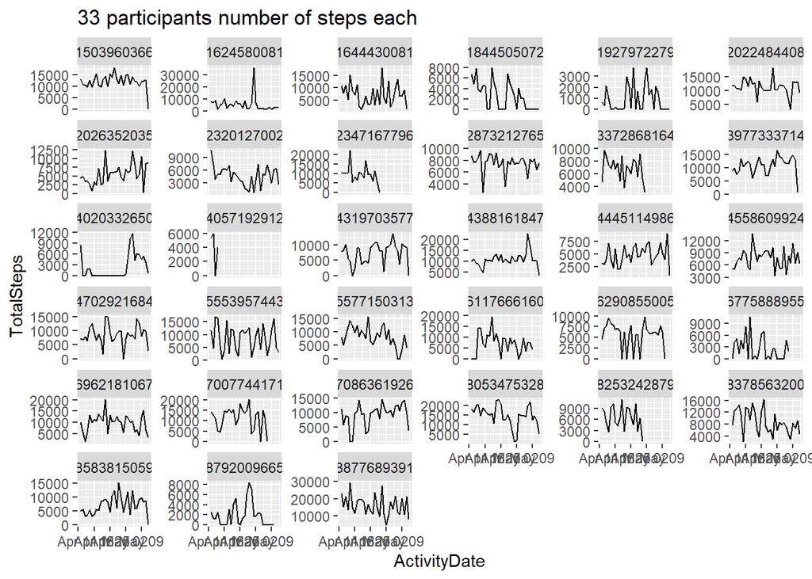

```r
data_day %>%
  ggplot((aes(x=ActivityDate , y=TotalSteps ))) + geom_line() + facet_wrap(~Id, scales = 'free_y') +
  labs(title = "33 participants number of steps each")
```

### You can see that the further the step distance, the greater amount of calories are used.This shows the fitbit device is working properly in recording data.

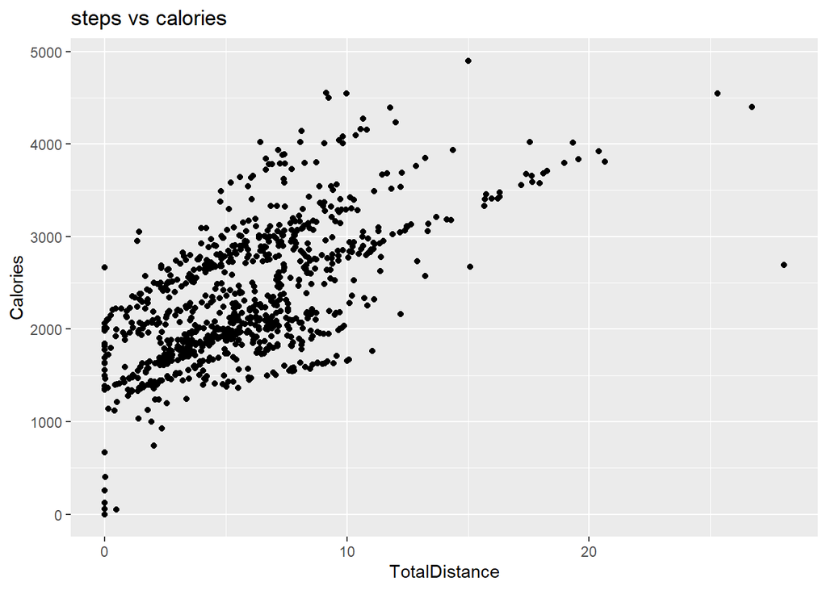

```r
data_day %>%
  ggplot(aes(x=TotalDistance , y=Calories)) + geom_point() + labs(title = "steps vs calories" )
```

### This graph shows there is a weak correlation with TotalMinuetsAsleep and TotalSteps where the least amount of steps is associated with greater amount of sleep.This was not expected.

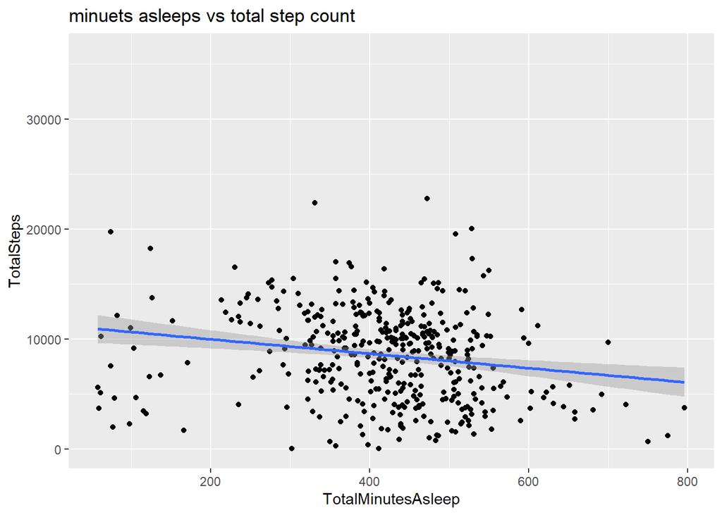

```r
data_day %>%
  left_join(data_sleep, by = c('ActivityDate'= 'SleepDay', 'Id' = 'Id')) %>%
  ggplot(aes(x=TotalMinutesAsleep, y=TotalSteps)) + geom_point()  + geom_smooth(method='lm') +
  labs(title = "minuets asleeps vs total step count")
```

### This correlation plot looks at the patterns of the different columns and shows the more active a subject is the greater amount of distance they go.This is expected.

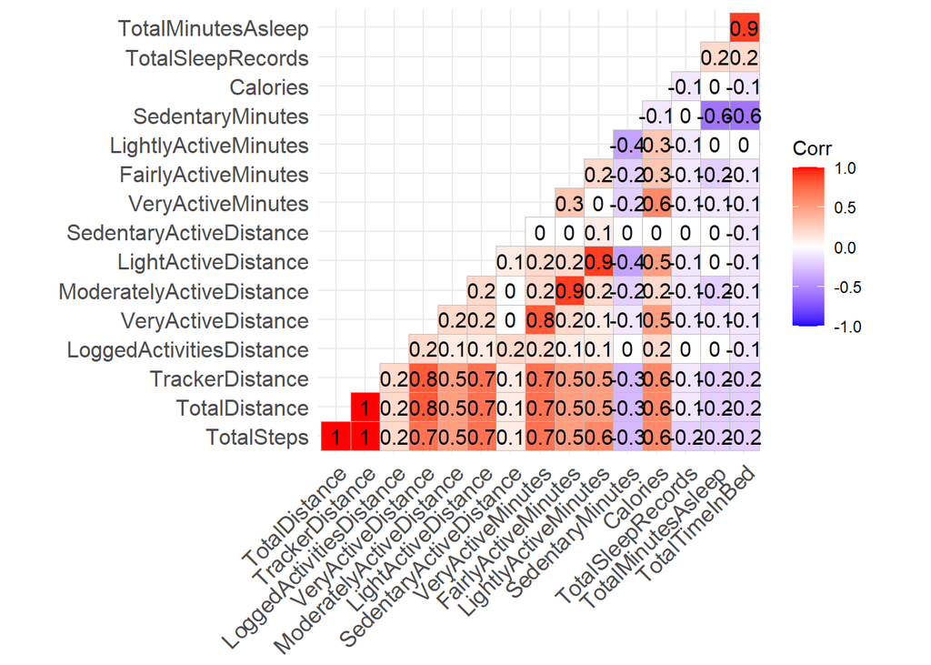

```r
data_day %>%
  left_join(data_sleep, by = c('ActivityDate'= 'SleepDay', 'Id' = 'Id')) %>%
  keep(is.numeric) %>%
  select(-Id) %>%
  cor(use = 'pairwise.complete.obs') %>%
  ggcorrplot(type = 'lower', lab=T, digits=1)
```

### This graph shows no correlation between Activity Day and number of steps.

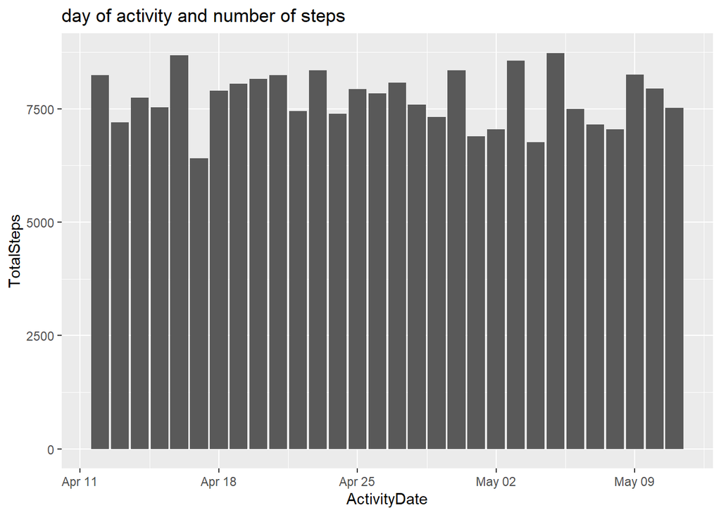

```r
data_day %>%
  group_by(ActivityDate) %>%
  summarise(TotalSteps = mean(TotalSteps)) %>%
  slice(-nrow(.)) %>%
  ggplot((aes(x=ActivityDate , y=TotalSteps ))) + geom_col()+
  labs(title = "day of activity and number of steps")
```

### This graph shows that LightlyActiveMinuets was by far the most common Activity state versus Fairly Active and Very Active.

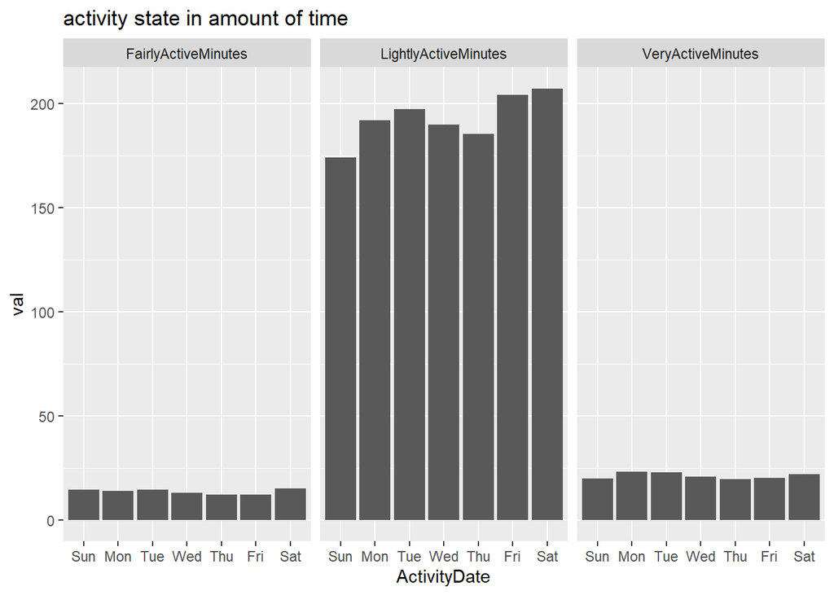

```r
data_day %>%
  group_by(ActivityDate = wday(ActivityDate, label=T)) %>%
  summarise_all('mean') %>%
  select(ActivityDate, VeryActiveMinutes, LightlyActiveMinutes, FairlyActiveMinutes) %>%
  gather(key, val, -ActivityDate) %>%
  ggplot((aes(x=ActivityDate , y= val ))) + geom_col(position = 'dodge') + facet_wrap(~key) +
  labs(title = "activity state in amount of time")
```

### After examining the results we find that the fitbit device was recording calories burned and number of steps correctly as well as distance vs number of steps. The calories increased with the number of steps. The longer sleep time associated with less steps was not expected and could be do to an error in the data collection or a true correlation within the data.

# Reccomendations for a company interested in their own fitbit device:

### We know that the cusumer wears the device during the day and night, so we could look for how many nights versus days each cusumer uses the device for further research.

### No day of the time period showed a higher activity level when compared with all the participants. However Sunday was a less active day for most. This could be do to Saturday, which was one of the more active days, needing Sunday to be a rest day.